# Techniques de l'IA - TD1 Analyse

22 septembre 2025 - Thanh Lam DANG

## Consignes

Vous remettrez sur Moodle pour le 5 octobre un rapport au format pdf de vos analyses qui inclut :

- Une introduction
- Une présentation de votre jeu de données
- Une technique d’analyse de données quantitatives : ACP
- Une technique d’analyse de données catégorielles/qualitatives
- Une conclusion qui résume l’ensemble de vos analyses

## 0. Importation des librairies

Ci-dessous vous importerez les librairies dont vous aurez besoins :

```python
import pandas as pd
import numpy as np
import seaborn as sns
import matplotlib.pyplot as plt
from sklearn.decomposition import PCA
from sklearn.preprocessing import StandardScaler
```

## 1. Validation et pré-traitement des données

Vous récupérerez des données sous format d'un ou plusieurs fichiers .csv et les lirez. Le jeu de données choisi comme exemple est Iris.

```python
df = pd.read_csv("iris.csv")
df.head()
```

|  | sepal.length | sepal.width | petal.length | petal.width | variety |
| --- | --- | --- | --- | --- | --- |
| 0 | 5.1 | 3.5 | 1.4 | 0.2 | Setosa |
| 1 | 4.9 | 3.0 | 1.4 | 0.2 | Setosa |
| 2 | 4.7 | 3.2 | 1.3 | 0.2 | Setosa |
| 3 | 4.6 | 3.1 | 1.5 | 0.2 | Setosa |
| 4 | 5.0 | 3.6 | 1.4 | 0.2 | Setosa |

Questions:

- Pourquoi avez-vous choisi ce jeu de données ?
- Quelles sont les caractéristiques ?
- Les données sont-elles propres ?
- Comment avez-vous les nettoyées (des valeurs manquantes/ aberrantes) ?

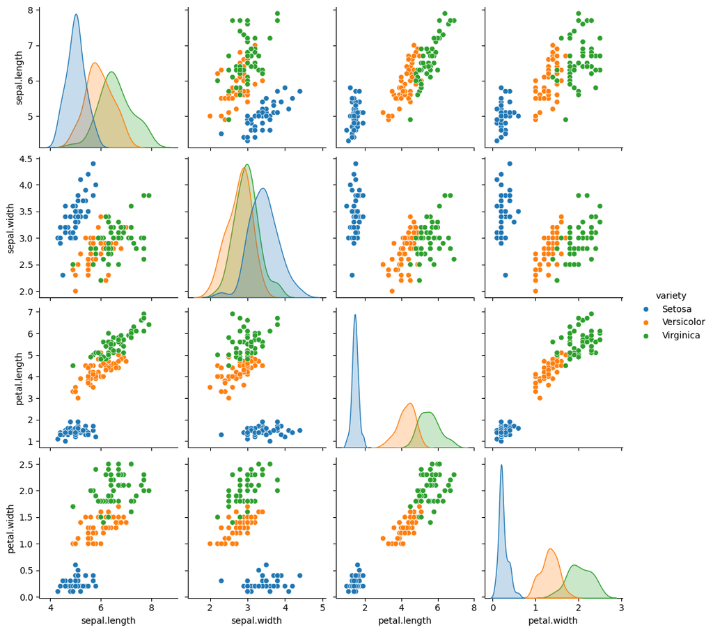

```python
### Visualisation des données
sns.pairplot(df, hue="variety")
```

Questions:

- Quelles sont les informations apportées par la visualisation ?
- Quelles sont les caractéristiques (features en anglais) discriminantes ?

## 2. Analyse en composantes principales (ACP)

### Standardisation

La standardisation (aussi appelée normalisation standard) consiste à soustraire la moyenne et à la diviser par l'écart type. La distribution résultante a une moyenne de 0 et un écart-type de 1.

```python
# Exclure la dernière colonne qui contient des étiquettes
X = df[df.columns[0:4]]
y = df["variety"]
temp = X.sub(X.mean())
X_scaled = temp.div(X.std())
```

Question: Pourquoi cette étape est nécessaire pour l'ACP ?

### Entraînement du modèle

Nous appelons `X_scaled` le jeu de valeur standardisées au quel nous appliquerons l’ACP. Dans l’exemple ci-dessous le nombre de composantes conservées est fixé à 3, vous changerez cette valeur en fonction de vos besoins.

```python
n_components = 3
pca = PCA(n_components=n_components)
pca.fit(X_scaled)
```

```
PCA(n_components=3)
```

`pca.fit` permet d’obtenir la modélisation de l’ACP. Afin d’obtenir les résultats pour les individus, il faut combiner les fonctions `fit()` et `transform()` de l’ACP. Une autre possibilité est d’utiliser la fonction `fit_transform()` qui réalise automatiquement la combinaison des deux.

```python
pca_res = pca.fit_transform(X_scaled)
```

### Calcul des valeurs propres

Parmi l’ensemble des valeurs de la PCA vous retrouverez :

Un tableau qui résume les valeurs propre est attendu:

- Les dimensions de votre ACP
- Les valeurs propres
- Le ratio de variance expliquée par chaque valeur propre
- Le ratio de variance expliquée cumulée

```python
eig = pd.DataFrame({
"Dimension" : [ "Dim" + str(x + 1) for x in range (n_components)] ,
"Valeur propre" : pca.explained_variance_ ,
"% variance expliquée" : np.round(pca.explained_variance_ratio_*100) ,
"% variance expliquée cumulée" : np.round(np.cumsum(pca.explained_variance_ratio_*100))
})
eig.head()
```

|  | Dimension | Valeur propre | % variance expliquée | % variance expliquée cumulée |
| --- | --- | --- | --- | --- |
| 0 | Dim1 | 2.918498 | 73.0 | 73.0 |
| 1 | Dim2 | 0.914030 | 23.0 | 96.0 |
| 2 | Dim3 | 0.146757 | 4.0 | 99.0 |

Une autre façon d'analyser les résultats des valeurs propres est de réaliser un diagramme bâton. Réaliserez ce diagramme dont l'abscisse sera composé de l'ensemble des dimensions de votre ACP et l'ordonnée les pourcentages de valeur propre.

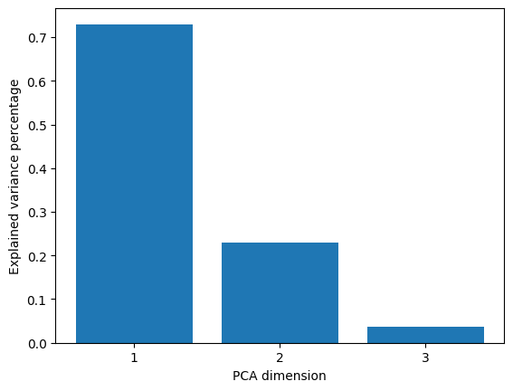

```python
y1 = list(pca.explained_variance_ratio_)
fig, ax = plt.subplots()
labels = [str(i+1).zfill(1) for i in range(n_components)]
ax.bar(labels, y1, label = labels)
ax.set_xlabel("PCA dimension")
ax.set_ylabel("Explained variance percentage")
plt.show()
```

### Visualisation des variables

Pour afficher le graphique des variables vous pouvez utiliser la fonction biplot ci-dessous.

```python
from scipy.spatial import ConvexHull
def biplot(pca=[],x=None,y=None,components=[0,1],score=None,\
           coeff=None,coeff_labels=None,score_labels=None,circle='T',\
           bigdata=1000,cat=None,cmap="viridis",density=True):
    if isinstance(pca,PCA)==True :
        coeff = np.transpose(pca.components_[components, :])
        score=  pca.fit_transform(x)[:,components]
        if isinstance(x,pd.DataFrame)==True :
            coeff_labels = list(x.columns)
    if score is not None : x = score
    if x.shape[1]>1 :
        xs = x[:,0]
        ys = x[:,1]
    else :
        xs = x
        ys = y
    if (len(xs) != len(ys)) : print("Warning ! x et y n'ont pas la même taille !")
    scalex = 1.0/(xs.max() - xs.min())
    scaley = 1.0/(ys.max() - ys.min())
    #x_c = xs * scalex
    #y_c = ys * scaley
    temp = (xs - xs.min())
    x_c = temp / temp.max() * 2 - 1
    temp = (ys - ys.min())
    y_c = temp / temp.max() * 2 - 1
    data = pd.DataFrame({"x_c":x_c,"y_c":y_c})
    print("Attention : pour des facilités d'affichage, les données sont centrées-réduites")
    if cat is None : cat = [0]*len(xs)
    elif len(pd.Series(cat)) == 1 : cat = list(pd.Series(cat))*len(xs)
    elif len(pd.Series(cat)) != len(xs) : print("Warning ! Nombre anormal de catégories !")
    cat = pd.Series(cat).astype("category")
    fig = plt.figure(figsize=(6,6),facecolor='w')
    ax = fig.add_subplot(111)
    # Affichage des points
    if (len(xs) < bigdata) :
        ax.scatter(x_c,y_c, c = cat.cat.codes,cmap=cmap)
        if density==True : print("Warning ! Le mode density actif n'apparait que si BigData est paramétré.")
    # Affichage des nappes convexes (BigData)
    else :
        #color
        norm = mpl.colors.Normalize(vmin=0, vmax=(len(np.unique(cat.cat.codes)))) #-(len(np.unique(c)))
        cmap = cmap
        m = cm.ScalarMappable(norm=norm, cmap=cmap)
        if density==True :
            sns.set_style("white")
            sns.kdeplot(x="x_c",y="y_c",data=data)
            if len(np.unique(cat)) <= 1 :
                sns.kdeplot(x="x_c",y="y_c",data=data, cmap="Blues", shade=True, thresh= 0)
            else :
                for i in np.unique(cat) :
                    color_temp = m.to_rgba(i)
                    sns.kdeplot(x="x_c",y="y_c",data=data[cat==i], color=color_temp,
                                shade=True, thresh=0.25, alpha=0.25)
        for cat_temp in cat.cat.codes.unique() :
            x_c_temp = [x_c[i] for i in range(len(x_c)) if (cat.cat.codes[i] == cat_temp)]
            y_c_temp = [y_c[i] for i in range(len(y_c)) if (cat.cat.codes[i] == cat_temp)]
            points = [ [ None ] * len(x_c_temp) ] * 2
            points = np.array(points)
            points = points.reshape(len(x_c_temp),2)
            points[:,0] = x_c_temp
            points[:,1] = y_c_temp
            hull = ConvexHull(points)
            temp = 0
            for simplex in hull.simplices:
                color_temp = m.to_rgba(cat_temp)
                plt.plot(points[simplex, 0], points[simplex, 1],color=color_temp)
                if (temp == 0) :
                     plt.xlim(-1,1)
                     plt.ylim(-1,1)
                     temp = temp+1
    if coeff is not None :
        if (circle == 'T'):
            x_circle = np.linspace(-1, 1, 100)
            y_circle = np.linspace(-1, 1, 100)
            X, Y = np.meshgrid(x_circle,y_circle)
            F = X**2 + Y**2 - 1.0
            #fig, ax = plt.subplots()
            plt.contour(X,Y,F,[0])
        n = coeff.shape[0]
        for i in range(n):
            plt.arrow(0, 0, coeff[i,0], coeff[i,1],color = 'r',alpha = 0.5,
                      head_width=0.05, head_length=0.05)
            if coeff_labels is None:
                plt.text(coeff[i,0]* 1.15, coeff[i,1] * 1.15, "Var"+str(i+1), color = 'g', ha = 'center', va = 'center')
            else:
                plt.text(coeff[i,0]* 1.15, coeff[i,1] * 1.15, coeff_labels[i], color = 'g', ha = 'center', va = 'center')
        if score_labels is not None :
            for i in range(len(score_labels)) :
                temp_x = xs[i] * scalex
                temp_y = ys[i] * scaley
                plt.text(temp_x,temp_y,list(score_labels)[i])
    plt.xlim(-1.2,1.2)
    plt.ylim(-1.2,1.2)
    plt.xlabel("PC{}".format(1))
    plt.ylabel("PC{}".format(2))
    plt.grid(linestyle='--')
    plt.show()
```

```
Attention : pour des facilités d'affichage, les données sont centrées-réduites
Warning ! Le mode density actif n'apparait que si BigData est paramétré.
```

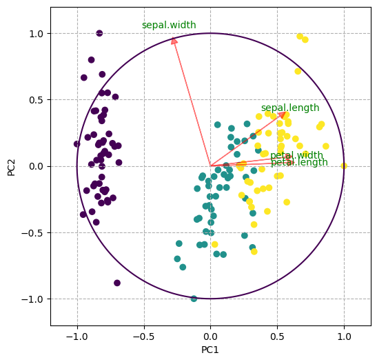

```python
biplot(score=pca_res[:,0:2],
    coeff=np.transpose(pca.components_[0:2, :]),
    cat=y,
    cmap="viridis",
    coeff_labels = list(X.columns))
plt.show()
```

Questions:

- Quelles sont les informations apportées par ce graphique ?
- Comment interprétez-vous ce graphique ?

### Visualisation des individus

Pour cette partie vous chercherez à afficher le graphique des individus de l’ACP. Pour ce faire vous pouvez commencer par créer un dataframe qui inclut les résultats des deux premières dimensions de l’ACP pour l’ensemble de vos individus. Vous ajouterez également à ce dataframe des variables catégorielles.

Dans un premier temps générez le graphique des individus de l’ACP sans distinction entre eux. Pour ce faire vous pouvez faire un dataframe qui inclut vos deux premières dimensions d’ACP. Vous pouvez également rajouter des données catégorielles qui nous serviront par la suite pour colorier les individus dans une représentation graphique plus avancée.

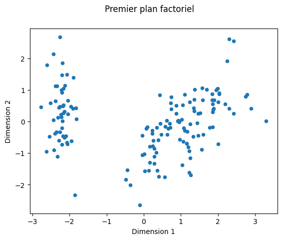

```python
pca_df = pd.DataFrame({
"Dim1" : pca_res[: , 0] ,
"Dim2" : pca_res[ : , 1] ,
"variety": y
})
pca_df.plot.scatter("Dim1", "Dim2")
plt.xlabel("Dimension 1")
plt.ylabel("Dimension 2")
plt.suptitle ("Premier plan factoriel")
plt.show()
```

Ensuite vous générerez un graphique en colorant les individus d’après une de vos variables catégorielles. Dans l’exemple suivant j’utilise ma variable catégorielle `variety`. Vous commencerez par créer une palette de couleur basée sur Color Brewer.

```python
palette = plt.get_cmap("Dark2")
couleurs = dict(zip(pca_df["variety"].drop_duplicates(), palette(range(10))))
```

Enfin vous afficherez le graphique des individus en coloriant ces dernier grâce à la palette des couleurs comme dans l’exemple ci-dessous. Je rappel que `variety` est dans la variable catégorielle utilisée pour la coloration.

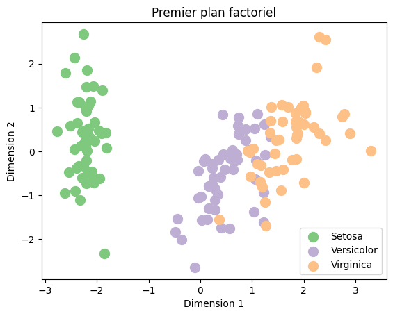

```python
# Iniate a figure for the scatter plot
fig, ax = plt.subplots(dpi=100)

# Define our colormap
cmap = plt.get_cmap('Accent')

# Create a scatter plot with Accent colormap
for i, (cat, df) in enumerate(pca_df.groupby('variety')):
   ax.scatter(df['Dim1'], df['Dim2'], label=cat, color=cmap(i), s=100)

# Add a legend
ax.legend()
ax.set_xlabel("Dimension 1")
ax.set_ylabel("Dimension 2")
ax.set_title ("Premier plan factoriel")
# Display the plot
plt.show()
```

Questions:

- Quelles sont les informations apportées par ce graphique ?
- Comment interprétez-vous ce graphique ?